# SVG Tutorial for spatialHeatmap

## 2.4 Add Text to Label Tissues

Users can add text to label tissues. Basically, the text is first typed in with the text tool and then the text object is coverted to paths. Next paths are added into the polygon group of target tissue and filled with the same tissue colour. Below is the example of adding text to the epidermis tissue.

13. Creat text paths

    Select “Creat and select text objects (F8)” from the left tool bar, drag a text box, and type epidermis. Click on the text object and convert it to path.
14. Text fill and stroke

    Click on the text paths and fill them with the same colour of epidermis using “Pick colors from image (F7)” from the left tool bar. In the “Fill and Stroke” panel, set the stroke style.
15. Add text paths to tissue group

    Click and cut the text, then double click epidermis (green) to enter the group.

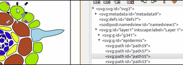

    Paste the text anywhere then the text is inside the epidermis group as a “text group”. Move/resize the text group as expected. Right click and ungroup the text.

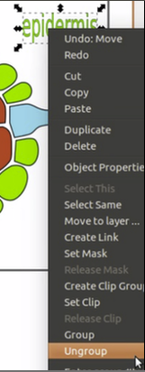

    All the letters are in the epidermis group as individual paths, which can be seen in the XML Editor.

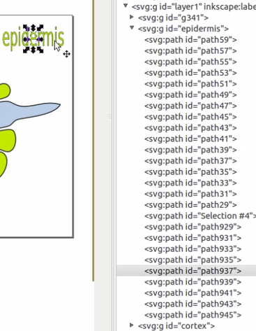

To add a pointer, draw a rectangle and convert it to path, fill it with the same style as epidermis. Move, rotate and resize it as expected.

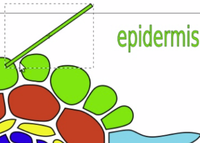

Clicking any of other tissues will group the text, pointer, and epidermis together, which can be confirmed by dragging epidermis to see they are moving as a whole.

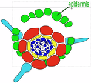

Similarly, add text to label other tissues.

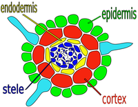

17. Save the final SVG image, which is ready to use in the spatialHeatmap. The name of saved SVG image can only consists of letters, digits, underscores. E.g. “root_cross_final.svg” is acceptable while “root_cross_final(copy).svg” will give errors.

## 2.5 Plot the spatial heatmaps

In Figure 1, user defined tissue regions are coloured by the expression profile of a target gene under different contidions. For example, in Table 1 the expression value of gene “PSAC” in “epidermis” under the condition “140mM_1h” is “2.457910”, after mapping the “epidermis” is coloured “dark yellow”, corresponsing to “2.457910” in the colour scale.

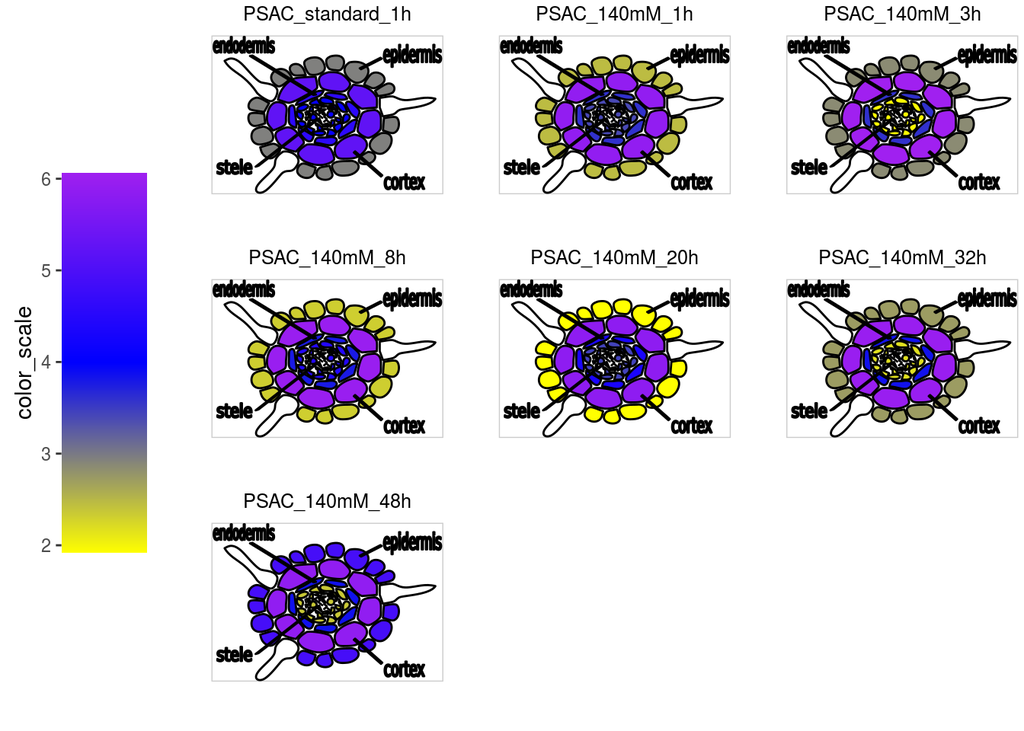

Figure 1. Spatial Heatmaps of the target gene “PSAC”. User defined tissue regions are coloured by the expression profile of the target gene.

```r
  # The path of the formatted SVG image as shown above.
  svg.path <- system.file("extdata/shinyApp/example", "root_cross_final.svg", package = "spatialHeatmap")
  # Mapping of the target gene "PSAC" to the SVG image. Multiple target genes can be mapped at the same time. Here only one is mapped. "exp" is the filtered expression matrix as shown above.
  spatial_hm(svg=svg.path, data=exp, pOA=c(0, 0), CV=c(0, 100), ID="PSAC", col.com=c("yellow", "blue", "purple"), width=1, height=1, sub.title.size=9.5, layout="gene", ncol=3)
```

## 2.6 Troubleshooting

1. Make sure the coloumn names are formatted in the right way.
2. Make sure the target tissue names are identical between data matrix and SVG. Even a dot, space, underscore, uppercase, or lowercase matters.
3. Make sure all the paths, groups are placed in a large group/layer as a whole in the XML editor.
4. Except for the large group/layer, make sure other groups contain only paths, no groups.
5. If some grouped polygons are absent in the spatial heatmaps, try to ungroup and regroup them in Inkscape.

# Reference

anatomybodysystem.com. 2017. “HEAD ANATOMY.” http://anatomybodysystem.com/lateral-view-of-the-brain-labeled/lateral-view-of-the-brain-labeled-brain-diagram-and-label-anatomy-body-list/.

Dowle, Matt, and Arun Srinivasan. 2018. *Data.table: Extension of ‘Data.frame‘*. https://CRAN.R-project.org/package=data.table.

epilepsyresearch. 2017. “The Hippocampus: What Is It?” https://www.epilepsyresearch.org.uk/the-hippocampus-what-is-it/.

Geng, Yu, Rui Wu, Choon Wei Wee, Fei Xie, Xueliang Wei, Penny Mei Yeen Chan, Cliff Tham, Lina Duan, and José R Dinneny. 2013. “A Spatio-Temporal Understanding of Growth Regulation During the Salt Stress Response in Arabidopsis.” *Plant Cell* 25 (6): 2132–54.

Gentleman, R, V Carey, W Huber, and F Hahne. 2018. “Genefilter: Methods for Filtering Genes from High-Throughput Experiments.” http://bioconductor.uib.no/2.7/bioc/html/genefilter.html.

Morgan, Martin, Valerie Obenchain, Jim Hester, and Hervé Pagès. 2018. *SummarizedExperiment: SummarizedExperiment Container*.

Mustroph, Angelika, M Eugenia Zanetti, Charles J H Jang, Hans E Holtan, Peter P Repetti, David W Galbraith, Thomas Girke, and Julia Bailey-Serres. 2009. “Profiling Translatomes of Discrete Cell Populations Resolves Altered Cellular Priorities During Hypoxia in Arabidopsis.” *Proc Natl Acad Sci U S A* 106 (44): 18843–8.

R Core Team. 2018. *R: A Language and Environment for Statistical Computing*. Vienna, Austria: R Foundation for Statistical Computing. https://www.R-project.org/.